# BCB420_Assignment3

Data set Pathway and Network Analysis

Mingzheng liu

04/04/2022

## Objective of Assignment 3

- To take the ranked data that was created in Assignment #2
- To perform non-thresholded pathway analysis
- To summarize and visualize your results using Cytoscape and the Enrichment map pipeline.

# Introduction

## General Background

The dataset is derived from genetically engineered Foxd1Cre;Smo(flox/-) house mice and aims to investigate the mRNA content of mutant kidneys to gain a deeper understanding of the molecular mechanisms underlying the developmental defects observed in the kidney. The Hedgehog-GLI pathway, which is responsible for the development and patterning of various tissues and organs, including the kidney, interacts with the transforming growth factor beta (TGF) signaling pathway, another critical regulator of kidney development. Smo, a key component of the Hedgehog-GLI signaling pathway, plays a crucial role in human kidney development and modulates TGFβ signaling in the kidney, and its disruption can lead to abnormal kidney development and function (Figure 1). The ultimate goal of understanding the role of Smo in these signaling pathways is to uncover the molecular mechanisms underlying normal kidney development and diseases, which could ultimately lead to the development of new therapeutic strategies for kidney disorders. (Christopher J. Rowan (2018))

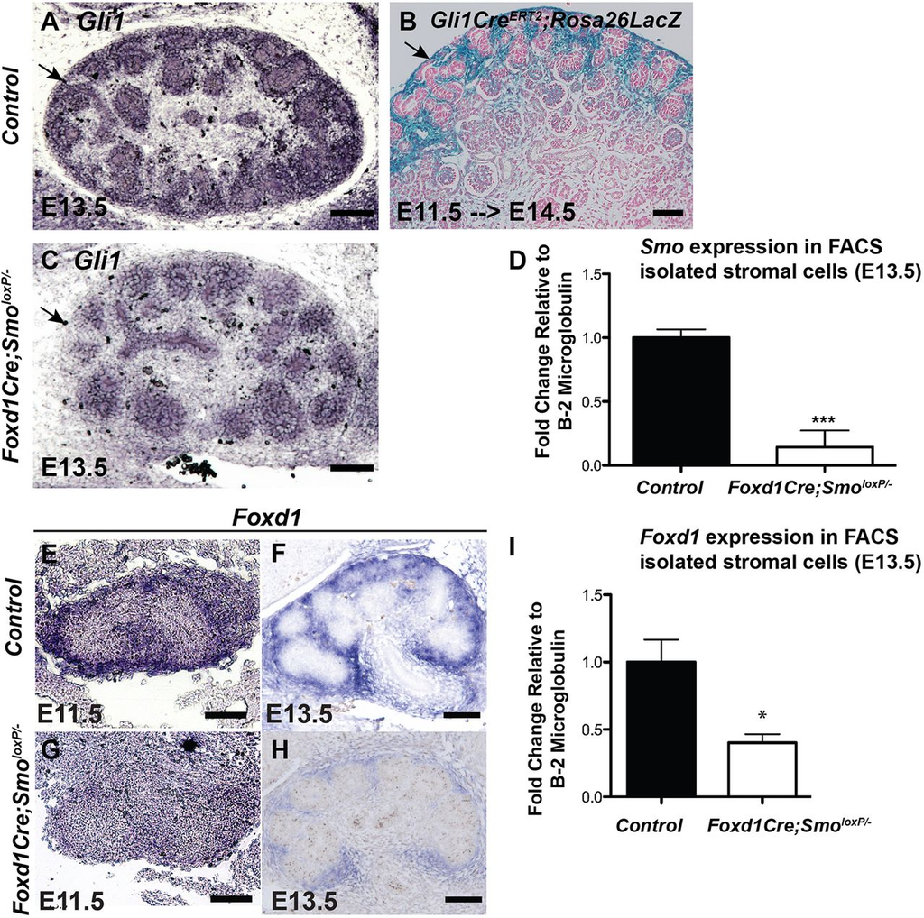

## Previous Work

In the previous work on the dataset with accession ID GSE103923, an initial processing of the data has been done, including accessing the dataset quality, filtering the low expression gene. The dataset was downloaded in a normalized data with identified as a mixed of HUGO symbol and he Mouse Genome Informatics (MGI) symbol. Hence, a identifier mapping was performed, and no extra normalization was applied. The result of assignment one is a clean, normalized dataset stored in the root directory as “smo_exp_normalized.txt”. The downloaded cleaned annotated dataset with calculated fold change and adjusted p-value is stored in the root directory as “smo_exp_annot.txt”

- Assignment 1 in htmlViewer can be found [here](https://htmlpreview.github.io/?https://github.com/bcb420-2023/Mingzheng_Liu/blob/main/Assignment1.html)

- Assignment 2 in htmlViewer can be found [here](https://htmlpreview.github.io/?https://github.com/bcb420-2023/Mingzheng_Liu/blob/main/A2_MingzhengLiu.html)

## Preparation

Tools are needed for the GSEA analysis. Packages used:

- R (R Core Team (2022))
- BiocManager (Morgan (2021))
- [knitr](https://yihui.org/knitr/) (Xie (2021))
- [ggplot2](https://ggplot2.tidyverse.org/) (Wickham (2010))
- [RCurl](https://cran.r-project.org/web/packages/RCurl/index.html) (Duncan Temple Lang (2020))
- [RCy3](https://bioconductor.org/packages/release/bioc/html/RCy3.html) (Muetze et al. (2015))

```r
if (!requireNamespace("BiocManager", quietly = TRUE))
  install.packages("BiocManager")
library(BiocManager)
if (!requireNamespace("knitr", quietly = TRUE))
  install.packages("knitr")
library(knitr)
if (!requireNamespace("ggplot2", quietly = TRUE))
  install.packages("ggplot2")
library(ggplot2)
if (!requireNamespace("RCurl", quietly = TRUE)){
  install.packages("RCurl")}
library(RCurl)
if (!requireNamespace("RCy3", quietly = TRUE)){
  BiocManager::install("RCy3")}
library(RCy3)
```

If running in a docker container, set is_docker to TRUE

```r
run_docker = FALSE # TRUE if running in docker container
base_url = "localhost:1234/v1"
if(run_docker){
  base_url = "host.docker.internal:1234/v1"
  .defaultBaseUrl <- "http://host.docker.internal:1234/v1"
}
```

## Prepare dataset from Assignment 2

###Step 1: Prepare gmt file The genesets used for GSEA analysis are collections of functionally related genes. The Bader lab geneset collection is chosen because it contains GO biological process pathways and curated pathway databases. These genesets help to identify functional themes among differentially expressed genes and to gain biological insights into the underlying mechanisms of the phenotype.

```r
# Download mouse GO to retrieve the gmt file
# Since we are using a mouse model, we use mouse GO
# Set url of baderlab to retrieve mouse GO
data_dir <- paste0(getwd(), "/")
gmt_url = "http://download.baderlab.org/EM_Genesets/current_release/Mouse/symbol/Mouse_GO_AllPathways_no_GO_iea_March_02_2023_symbol.gmt"
# retrieve mouse GO
if (!file.exists("Mouse_GO.gmt")) {
  download.file(gmt_url, "Mouse_GO.gmt")
}
# get the gmt file path
dest_gmt_file <- paste0(data_dir, "Mouse_GO.gmt")
```

###Step 2: Prepare rnk file The ranked list is used to provide a score for each gene based on their differential expression between the two subtypes. The scores are used to determine the position of the gene in the ranked list, which is a crucial input for GSEA analysis.

```r
# Since the dataset is pre-normalized with logFC and adjusted p-value
# We make the rnk file from the cleaned dataset

# Load the differential expression analysis results from previous work
de_results <- read.table("smo_exp_annot.txt", header=TRUE)

# calculate rank for each gene
de_results[,"rank"] <- -log(de_results$padj, 10) * sign(de_results$log2FoldChange)
de_results <- de_results[order(de_results$rank),]

# Combine the rank, gene IDs
rnk <- cbind(de_results$id, de_results$rank)
colnames(rnk) <- c("GeneID", "rank")

# Save the rnk file
if (!file.exists("smo_exp.rnk")) {
write.table(rnk, file="smo_exp.rnk", quote=FALSE, sep="\t", row.names=FALSE)
}
```